# Do Known Mutual Fund Brands Outperform?

[Return to Homepage](https://mathiassteilen.github.io/)

[Return to Data Visualisation Section](https://mathiassteilen.github.io/dataviz.html)

[figure not shown]

### The Data

The data for this post comes from the [CRSP Survivor-Bias-Free US Mutual Fund data base](https://www.crsp.org/products/documentation/crsp-survivor-bias-free-us-mutual-fund-guide-crspsift). It has been filtered for active equity mutual funds larger than USD 20 MM and aggregated to yearly values.

The question is: How have mutual funds from better known fund managers performed as opposed to mutual funds from lesser known fund managers. Let’s first look at the performance of the entire sample.

### How Have Equity Mutual Funds Performed Over The Past Two Decades?

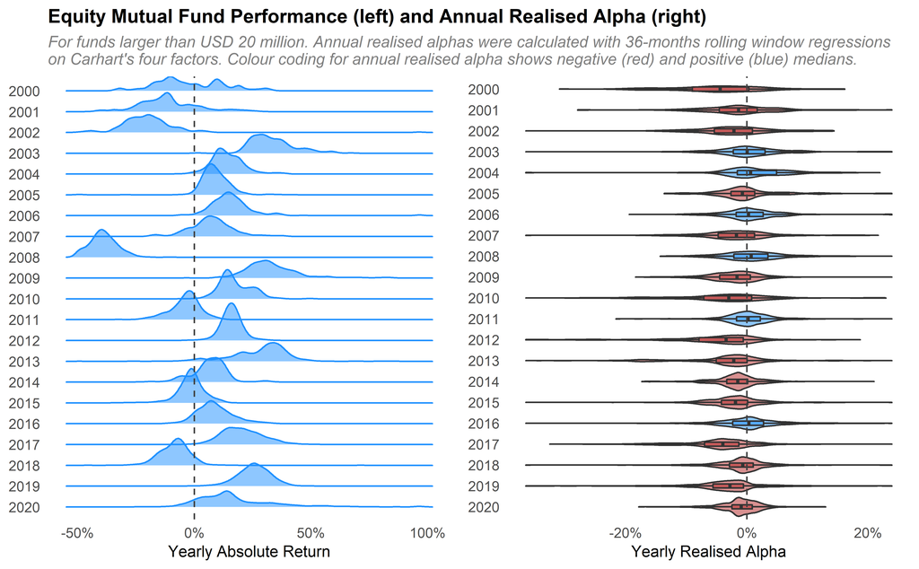

```r
gg1 <- funds %>%
  filter(between(year, 2000, 2020)) %>%
  mutate(year = factor(year) %>% fct_rev()) %>%
  ggplot(aes(y = year, x = yret)) +
  geom_density_ridges(fill = "dodgerblue", colour = "dodgerblue",
                      alpha = 0.5) +
  geom_vline(xintercept = 0, lty = "dashed", colour = "grey25") +
  labs(y = NULL,
       x = "Yearly Absolute Return",
       title = "Equity Mutual Fund Performance (left) and Annual Realised Alpha (right)",
       subtitle = "For funds larger than USD 20 million. Annual realised alphas were calculated with 36-months rolling window regressions\non Carhart's four factors. Colour coding for annual realised alpha shows negative (red) and positive (blue) medians.") +
  theme_minimal() +
  theme(panel.grid = element_blank(),
        plot.title = element_text(size = 12, face="bold", colour="black"),
        plot.subtitle = element_text(face = "italic", colour = "gray50",
                                     size = 10),
        axis.title = element_text(size = 10)) +
  scale_x_continuous(labels = scales::percent_format())

gg2 <- funds %>%
  filter(between(year, 2000, 2020)) %>%
  group_by(year) %>%
  mutate(mean_alpha = median(yrea_alpha_lagged)) %>%
  ungroup() %>%
  mutate(year = factor(year) %>% fct_rev(),
         colour = ifelse(mean_alpha < 0,
                         "Negative Median Alpha",
                         "Positive Median Alpha")) %>%
  ggplot(aes(x = yrea_alpha_lagged, y = year, fill = colour)) +
  geom_violin(alpha = 0.5) +
  geom_boxplot(outlier.colour = NA, width = 0.2, alpha = 0.5) +
  geom_vline(xintercept = 0, lty = "dashed", colour = "gray25") +
  scale_fill_manual(values = c("firebrick", "dodgerblue")) +
  labs(y = NULL,
       x = "Yearly Realised Alpha",
       title = "",
       subtitle = "\n",
       fill = NULL) +
  theme_minimal() +
  theme(panel.grid = element_blank(),
        plot.title = element_text(size = 12, face="bold", colour="black"),
        plot.subtitle = element_text(face = "italic", colour = "gray50",
                                     size = 10),
        axis.title = element_text(size = 10),
        legend.position = "none") +
  scale_x_continuous(labels = scales::percent_format())

grid.arrange(gg1, gg2, ncol = 2)
```

### How Do Funds By Well Known Managers Differ From Lesser Known Funds?

```r
dt %>% count(mgmt_name, sort = T)
```

| mgmt_name | n |
| --- | --- |
| Fidelity Management & Research Company | 1455 |
| American Funds | 1030 |
| MFS Investment Management | 744 |
| Directed Services LLC | 663 |
| John Hancock Group | 662 |
| John Hancock Life Insurance Company | 650 |
| Lincoln Investment Advisors Corporation | 608 |
| JPMorgan Funds | 607 |
| American Century Investment Mgmt Inc | 596 |
| MassMutual Life Insurance Company | 556 |

[output cut: 836 more lines]

There are 846 different management companies in the dataset. The big question is how to separate them into better and lesser known brands.

Better known brands probably have higher TNA across all their funds, as they attract more assets on average. However, this is not a very sophisticated approach, as subsidiaries of large and well known fund managers will slip into the “lesser known” bracket. Furthermore, if an investment company has some very large or very small funds deviating from their mean, this will also affect their status as “well known” or “less well known”. In this case of a short blog post however, this approach of using average fund size by investment firm will be sufficient. The TNA threshold set here is USD 200 MM, as it ensures balanced groups.

```r
top_managers <- dt %>%
  group_by(mgmt_name) %>%
  summarise(mean_tna = mean(tna_latest)) %>%
  arrange(desc(mean_tna)) %>%
  filter(mean_tna > 200) %>%
  pull(mgmt_name)

bottom_managers <- dt %>%
  group_by(mgmt_name) %>%
  summarise(mean_tna = mean(tna_latest)) %>%
  arrange(desc(mean_tna)) %>%
  filter(mean_tna <= 200) %>%
  pull(mgmt_name)
```

Having split the group into two subgroups, select characteristics can now be analysed by averaging both groups over time:

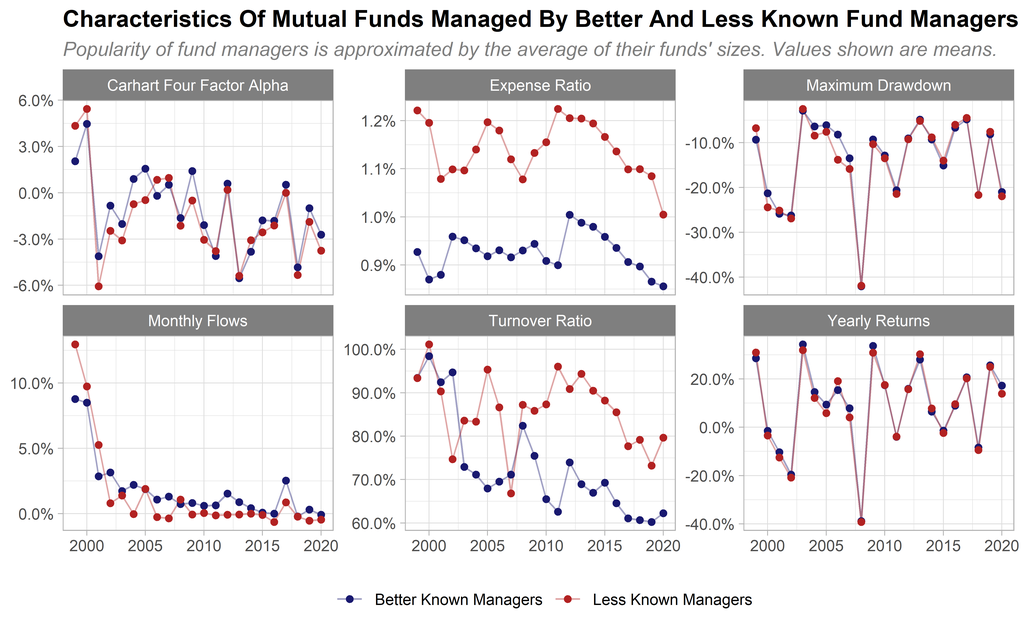

```r
facet_labels <- c("mean_alpha" = "Carhart Four Factor Alpha",
                  "mean_exp_ratio" = "Expense Ratio",
                  "mean_max_drawdown" = "Maximum Drawdown",
                  "mean_mflows" = "Monthly Flows",
                  "mean_turn_ratio" = "Turnover Ratio",
                  "mean_yret" = "Yearly Returns")

bind_rows(
  dt %>%
    filter(mgmt_name %in% top_managers) %>%
    mutate(class = "Better Known Managers") %>%
    group_by(year) %>%
    summarise(mean_alpha = mean(yrea_alpha),
              mean_exp_ratio = mean(exp_ratio),
              mean_turn_ratio = mean(turn_ratio),
              mean_yret = mean(yret),
              mean_max_drawdown = mean(max_drawdown),
              mean_mflows = mean(mflows),
              class = last(class)),
  dt %>%
    filter(mgmt_name %in% bottom_managers) %>%
    mutate(class = "Less Known Managers") %>%
    group_by(year) %>%
    summarise(mean_alpha = mean(yrea_alpha),
              mean_exp_ratio = mean(exp_ratio),
              mean_turn_ratio = mean(turn_ratio),
              mean_yret = mean(yret),
              mean_max_drawdown = mean(max_drawdown),
              mean_mflows = mean(mflows),
              class = last(class))
) %>%
  pivot_longer(-c(year, class)) %>%
  ggplot(aes(year, value, colour = class)) +
  geom_line(alpha = 0.4) +
  geom_point() +
  facet_wrap(~ name,
             scales = "free_y",
             labeller = as_labeller(facet_labels)) +
  labs(title = "Characteristics Of Mutual Funds Managed By Better And Less Known Fund Managers",
       subtitle = "Popularity of fund managers is approximated by the average of their funds' sizes. Values shown are means.",
       x = NULL,
       y = NULL,
       colour = NULL) +
  scale_colour_manual(values = c("midnightblue", "firebrick")) +
  scale_y_continuous(labels = scales::percent_format(accuracy = 0.1)) +
  theme_light() +
  theme(strip.background = element_rect(fill = "grey50"),
        plot.title = element_text(face = "bold"),
        plot.subtitle = element_text(face = "italic", colour = "grey50"),
        legend.position = "bottom")
```

Looking at the four factor Carhart alpha, there exists an ever so slight and inconsistent outperformance of equity mutual funds from better known managers. The same holds for monthly flows. Yearly returns show no discernible difference.

However, there are two fund characteristics which reveal an interesting disparity. Both expense ratios and turnover ratios of lesser known fund managers are considerably higher. As higher turnover is directly correlated with higher expenses, the two could be considered to be two sides of the same coin.

Even though no causation can be implied here, it is likely the case that investors are sensitive to expense ratios and prefer funds with lower expense ratios, in turn leaving more annual performance on the table, though it can be said that both groups are very comparable from a performance perspective on average.

A work by [Mathias Steilen](https://www.linkedin.com/in/mathias-steilen/)